# Week 9 Tables + More Time

Statistics 422

# Tables

### Setup

```r
library(readr)
library(tidyverse)
library(knitr)
library(gt)
library(gtExtras)
library(gtsummary)
library(reactable)
options(dplyr.width = Inf, dplyr.print_max = 1e9,  width = 144)
```

### Stock Prices

```r
NVIDIA <- read_csv("https://raw.githubusercontent.com/lewv/sp25stats21/refs/heads/main/data/NVDA.csv")
kable(glimpse(NVIDIA))
```

```
Rows: 291
Columns: 7
$ Date        <date> 2023-01-03, 2023-01-04, 2023-01-05, 2023-01-06, 2023-01-09, 2023-01-10, 2023-01-11, 2023-01-12, 2023-01-13, 2023-01-17, 2…
$ Open        <dbl> 148.51, 145.67, 144.91, 144.74, 152.84, 155.07, 158.40, 161.00, 162.78, 168.99, 176.67, 170.36, 170.11, 180.64, 188.27, 18…
$ High        <dbl> 149.96, 148.53, 145.64, 150.10, 160.56, 159.62, 160.28, 166.37, 169.22, 177.28, 178.73, 171.97, 178.56, 192.45, 194.95, 19…
$ Low         <dbl> 140.96, 142.41, 141.48, 140.34, 151.41, 154.72, 155.63, 154.92, 161.65, 168.99, 172.82, 167.31, 168.25, 178.18, 188.20, 18…
$ Close       <dbl> 143.15, 147.49, 142.65, 148.59, 156.28, 159.09, 160.01, 165.11, 168.99, 177.02, 173.77, 167.65, 178.39, 191.93, 192.65, 19…
$ `Adj Close` <dbl> 143.0798, 147.4177, 142.5800, 148.5171, 156.2034, 159.0120, 159.9315, 165.0291, 168.9071, 176.9332, 173.6848, 167.5678, 17…
$ Volume      <dbl> 40127700, 43132400, 38916800, 40504400, 50423100, 38410100, 35328500, 55140900, 44728700, 51110200, 43962400, 45293200, 56…
```

| Date | Open | High | Low | Close | Adj Close | Volume |
| --- | --- | --- | --- | --- | --- | --- |
| 2023-01-03 | 148.51 | 149.96 | 140.96 | 143.15 | 143.0798 | 40127700 |
| 2023-01-04 | 145.67 | 148.53 | 142.41 | 147.49 | 147.4177 | 43132400 |
| 2023-01-05 | 144.91 | 145.64 | 141.48 | 142.65 | 142.5800 | 38916800 |
| 2023-01-06 | 144.74 | 150.10 | 140.34 | 148.59 | 148.5171 | 40504400 |
| 2023-01-09 | 152.84 | 160.56 | 151.41 | 156.28 | 156.2034 | 50423100 |
| 2023-01-10 | 155.07 | 159.62 | 154.72 | 159.09 | 159.0120 | 38410100 |
| 2023-01-11 | 158.40 | 160.28 | 155.63 | 160.01 | 159.9315 | 35328500 |
| 2023-01-12 | 161.00 | 166.37 | 154.92 | 165.11 | 165.0291 | 55140900 |
| 2023-01-13 | 162.78 | 169.22 | 161.65 | 168.99 | 168.9071 | 44728700 |
| 2023-01-17 | 168.99 | 177.28 | 168.99 | 177.02 | 176.9332 | 51110200 |
| 2023-01-18 | 176.67 | 178.73 | 172.82 | 173.77 | 173.6848 | 43962400 |
| 2023-01-19 | 170.36 | 171.97 | 167.31 | 167.65 | 167.5678 | 45293200 |
| 2023-01-20 | 170.11 | 178.56 | 168.25 | 178.39 | 178.3025 | 56496700 |
| 2023-01-23 | 180.64 | 192.45 | 178.18 | 191.93 | 191.8359 | 65516300 |
| 2023-01-24 | 188.27 | 194.95 | 188.20 | 192.65 | 192.5555 | 49620400 |
| 2023-01-25 | 189.13 | 193.70 | 185.80 | 193.23 | 193.1352 | 44953700 |
| 2023-01-26 | 197.01 | 201.66 | 192.78 | 198.02 | 197.9229 | 48953500 |
| 2023-01-27 | 194.62 | 206.28 | 194.05 | 203.65 | 203.5501 | 54214200 |
| 2023-01-30 | 199.50 | 201.40 | 191.50 | 191.62 | 191.5260 | 48861100 |
| 2023-01-31 | 191.70 | 196.87 | 189.50 | 195.37 | 195.2742 | 49801700 |
| 2023-02-01 | 196.91 | 211.92 | 196.11 | 209.43 | 209.3273 | 66047700 |
| 2023-02-02 | 210.00 | 219.49 | 207.00 | 217.09 | 216.9835 | 56427600 |
| 2023-02-03 | 210.00 | 217.45 | 207.89 | 211.00 | 210.8965 | 42936600 |
| 2023-02-06 | 208.06 | 215.70 | 207.86 | 210.89 | 210.7866 | 45219700 |
| 2023-02-07 | 213.82 | 222.59 | 211.50 | 221.73 | 221.6213 | 66415000 |
| 2023-02-08 | 223.87 | 228.78 | 220.08 | 222.05 | 221.9411 | 55965100 |
| 2023-02-09 | 226.06 | 230.20 | 221.20 | 223.37 | 223.2605 | 52387600 |
| 2023-02-10 | 216.90 | 220.78 | 208.11 | 212.65 | 212.5457 | 55073700 |
| 2023-02-13 | 215.38 | 220.48 | 209.62 | 217.88 | 217.7732 | 47491900 |
| 2023-02-14 | 215.78 | 230.49 | 213.66 | 229.71 | 229.5974 | 67547400 |

[output cut: 261 more lines]

### Standard knitr table

This is standard if you use Quarto (highly recommended) or R Markdown to produce reports or slides. Just wrap kable() around objects that are more or less rectangular:

```r
kable(NVIDIA)
```

| Date | Open | High | Low | Close | Adj Close | Volume |
| --- | --- | --- | --- | --- | --- | --- |
| 2023-01-03 | 148.51 | 149.96 | 140.96 | 143.15 | 143.0798 | 40127700 |
| 2023-01-04 | 145.67 | 148.53 | 142.41 | 147.49 | 147.4177 | 43132400 |
| 2023-01-05 | 144.91 | 145.64 | 141.48 | 142.65 | 142.5800 | 38916800 |
| 2023-01-06 | 144.74 | 150.10 | 140.34 | 148.59 | 148.5171 | 40504400 |
| 2023-01-09 | 152.84 | 160.56 | 151.41 | 156.28 | 156.2034 | 50423100 |
| 2023-01-10 | 155.07 | 159.62 | 154.72 | 159.09 | 159.0120 | 38410100 |
| 2023-01-11 | 158.40 | 160.28 | 155.63 | 160.01 | 159.9315 | 35328500 |
| 2023-01-12 | 161.00 | 166.37 | 154.92 | 165.11 | 165.0291 | 55140900 |
| 2023-01-13 | 162.78 | 169.22 | 161.65 | 168.99 | 168.9071 | 44728700 |
| 2023-01-17 | 168.99 | 177.28 | 168.99 | 177.02 | 176.9332 | 51110200 |
| 2023-01-18 | 176.67 | 178.73 | 172.82 | 173.77 | 173.6848 | 43962400 |
| 2023-01-19 | 170.36 | 171.97 | 167.31 | 167.65 | 167.5678 | 45293200 |
| 2023-01-20 | 170.11 | 178.56 | 168.25 | 178.39 | 178.3025 | 56496700 |
| 2023-01-23 | 180.64 | 192.45 | 178.18 | 191.93 | 191.8359 | 65516300 |
| 2023-01-24 | 188.27 | 194.95 | 188.20 | 192.65 | 192.5555 | 49620400 |
| 2023-01-25 | 189.13 | 193.70 | 185.80 | 193.23 | 193.1352 | 44953700 |
| 2023-01-26 | 197.01 | 201.66 | 192.78 | 198.02 | 197.9229 | 48953500 |
| 2023-01-27 | 194.62 | 206.28 | 194.05 | 203.65 | 203.5501 | 54214200 |
| 2023-01-30 | 199.50 | 201.40 | 191.50 | 191.62 | 191.5260 | 48861100 |
| 2023-01-31 | 191.70 | 196.87 | 189.50 | 195.37 | 195.2742 | 49801700 |
| 2023-02-01 | 196.91 | 211.92 | 196.11 | 209.43 | 209.3273 | 66047700 |
| 2023-02-02 | 210.00 | 219.49 | 207.00 | 217.09 | 216.9835 | 56427600 |
| 2023-02-03 | 210.00 | 217.45 | 207.89 | 211.00 | 210.8965 | 42936600 |
| 2023-02-06 | 208.06 | 215.70 | 207.86 | 210.89 | 210.7866 | 45219700 |
| 2023-02-07 | 213.82 | 222.59 | 211.50 | 221.73 | 221.6213 | 66415000 |
| 2023-02-08 | 223.87 | 228.78 | 220.08 | 222.05 | 221.9411 | 55965100 |
| 2023-02-09 | 226.06 | 230.20 | 221.20 | 223.37 | 223.2605 | 52387600 |
| 2023-02-10 | 216.90 | 220.78 | 208.11 | 212.65 | 212.5457 | 55073700 |
| 2023-02-13 | 215.38 | 220.48 | 209.62 | 217.88 | 217.7732 | 47491900 |
| 2023-02-14 | 215.78 | 230.49 | 213.66 | 229.71 | 229.5974 | 67547400 |

[output cut: 261 more lines]

# Try gt()

### gt()

gt is a package specifically for producing tables and allows much classification. Data is converted to a gt object and then formatting is applied.

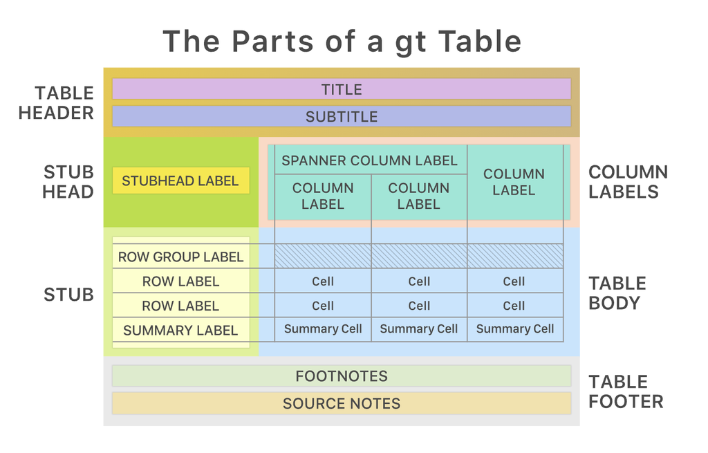

### gt() with formatting

Same data as before, just formatted using gt() and only showing the first 20 rows:

```r
start_date <- min(NVIDIA$Date)
end_date <- max(NVIDIA$Date)
NVIDIA[1:20,] |>
  gt() |>
   fmt_currency(columns = -Volume) |>
   fmt_date(columns = Date, date_style = "wd_m_day_year") |>
   fmt_number(columns = 7, decimals = 0, sep_mark = ",", dec_mark = ".")
```

| Date | Open | High | Low | Close | Adj Close | Volume |
| --- | --- | --- | --- | --- | --- | --- |
| Tue, Jan 3, 2023 | $148.51 | $149.96 | $140.96 | $143.15 | $143.08 | 40,127,700 |
| Wed, Jan 4, 2023 | $145.67 | $148.53 | $142.41 | $147.49 | $147.42 | 43,132,400 |
| Thu, Jan 5, 2023 | $144.91 | $145.64 | $141.48 | $142.65 | $142.58 | 38,916,800 |
| Fri, Jan 6, 2023 | $144.74 | $150.10 | $140.34 | $148.59 | $148.52 | 40,504,400 |
| Mon, Jan 9, 2023 | $152.84 | $160.56 | $151.41 | $156.28 | $156.20 | 50,423,100 |
| Tue, Jan 10, 2023 | $155.07 | $159.62 | $154.72 | $159.09 | $159.01 | 38,410,100 |
| Wed, Jan 11, 2023 | $158.40 | $160.28 | $155.63 | $160.01 | $159.93 | 35,328,500 |
| Thu, Jan 12, 2023 | $161.00 | $166.37 | $154.92 | $165.11 | $165.03 | 55,140,900 |
| Fri, Jan 13, 2023 | $162.78 | $169.22 | $161.65 | $168.99 | $168.91 | 44,728,700 |
| Tue, Jan 17, 2023 | $168.99 | $177.28 | $168.99 | $177.02 | $176.93 | 51,110,200 |
| Wed, Jan 18, 2023 | $176.67 | $178.73 | $172.82 | $173.77 | $173.68 | 43,962,400 |
| Thu, Jan 19, 2023 | $170.36 | $171.97 | $167.31 | $167.65 | $167.57 | 45,293,200 |
| Fri, Jan 20, 2023 | $170.11 | $178.56 | $168.25 | $178.39 | $178.30 | 56,496,700 |
| Mon, Jan 23, 2023 | $180.64 | $192.45 | $178.18 | $191.93 | $191.84 | 65,516,300 |
| Tue, Jan 24, 2023 | $188.27 | $194.95 | $188.20 | $192.65 | $192.56 | 49,620,400 |
| Wed, Jan 25, 2023 | $189.13 | $193.70 | $185.80 | $193.23 | $193.14 | 44,953,700 |
| Thu, Jan 26, 2023 | $197.01 | $201.66 | $192.78 | $198.02 | $197.92 | 48,953,500 |
| Fri, Jan 27, 2023 | $194.62 | $206.28 | $194.05 | $203.65 | $203.55 | 54,214,200 |
| Mon, Jan 30, 2023 | $199.50 | $201.40 | $191.50 | $191.62 | $191.53 | 48,861,100 |
| Tue, Jan 31, 2023 | $191.70 | $196.87 | $189.50 | $195.37 | $195.27 | 49,801,700 |

### gt() with header and note

Showing few rows, adding a table header and a source note:

```r
start_date <- min(NVIDIA$Date)
end_date <- max(NVIDIA$Date)
NVIDIA[1:6,] |>
  gt() |>
  tab_header(
    title = md("**NVIDIA**"),
    subtitle = glue::glue("{start_date} to {end_date}")
  ) |>
  fmt_currency(columns = -Volume) |>
  fmt_number(columns = Volume, decimals = 0, sep_mark = ",", dec_mark = ".") |>
  fmt_date(columns = Date, date_style = "wd_m_day_year") |>
 tab_source_note(
    source_note = md("**Source: Yahoo Finance**")
  )
```

**NVIDIA**

2023-01-03 to 2024-02-29

| Date | Open | High | Low | Close | Adj Close | Volume |
| --- | --- | --- | --- | --- | --- | --- |
| Tue, Jan 3, 2023 | $148.51 | $149.96 | $140.96 | $143.15 | $143.08 | 40,127,700 |
| Wed, Jan 4, 2023 | $145.67 | $148.53 | $142.41 | $147.49 | $147.42 | 43,132,400 |
| Thu, Jan 5, 2023 | $144.91 | $145.64 | $141.48 | $142.65 | $142.58 | 38,916,800 |
| Fri, Jan 6, 2023 | $144.74 | $150.10 | $140.34 | $148.59 | $148.52 | 40,504,400 |
| Mon, Jan 9, 2023 | $152.84 | $160.56 | $151.41 | $156.28 | $156.20 | 50,423,100 |
| Tue, Jan 10, 2023 | $155.07 | $159.62 | $154.72 | $159.09 | $159.01 | 38,410,100 |

**Source: Yahoo Finance**

### gt() with stubhead

```r
start_date <- min(NVIDIA$Date)
end_date <- max(NVIDIA$Date)
NVIDIA |>
  gt(rowname_col = "Date") |>
  tab_header(
    title = md("**NVIDIA**"),
    subtitle = glue::glue("{start_date} to {end_date}")
  ) |>
  tab_stubhead(label = "Date") |>
  fmt_currency(columns = -Volume) |>
  fmt_number(columns = Volume, decimals = 0, sep_mark = ",", dec_mark = ".") |>
  fmt_date(columns = Date, date_style = "wd_m_day_year") |>
 tab_source_note(
    source_note = md("**Source: Yahoo Finance**")
  )
```

**NVIDIA**

2023-01-03 to 2024-02-29

| Date | Open | High | Low | Close | Adj Close | Volume |
| --- | --- | --- | --- | --- | --- | --- |
| Tue, Jan 3, 2023 | $148.51 | $149.96 | $140.96 | $143.15 | $143.08 | 40,127,700 |
| Wed, Jan 4, 2023 | $145.67 | $148.53 | $142.41 | $147.49 | $147.42 | 43,132,400 |
| Thu, Jan 5, 2023 | $144.91 | $145.64 | $141.48 | $142.65 | $142.58 | 38,916,800 |
| Fri, Jan 6, 2023 | $144.74 | $150.10 | $140.34 | $148.59 | $148.52 | 40,504,400 |
| Mon, Jan 9, 2023 | $152.84 | $160.56 | $151.41 | $156.28 | $156.20 | 50,423,100 |
| Tue, Jan 10, 2023 | $155.07 | $159.62 | $154.72 | $159.09 | $159.01 | 38,410,100 |
| Wed, Jan 11, 2023 | $158.40 | $160.28 | $155.63 | $160.01 | $159.93 | 35,328,500 |
| Thu, Jan 12, 2023 | $161.00 | $166.37 | $154.92 | $165.11 | $165.03 | 55,140,900 |
| Fri, Jan 13, 2023 | $162.78 | $169.22 | $161.65 | $168.99 | $168.91 | 44,728,700 |
| Tue, Jan 17, 2023 | $168.99 | $177.28 | $168.99 | $177.02 | $176.93 | 51,110,200 |
| Wed, Jan 18, 2023 | $176.67 | $178.73 | $172.82 | $173.77 | $173.68 | 43,962,400 |
| Thu, Jan 19, 2023 | $170.36 | $171.97 | $167.31 | $167.65 | $167.57 | 45,293,200 |
| Fri, Jan 20, 2023 | $170.11 | $178.56 | $168.25 | $178.39 | $178.30 | 56,496,700 |
| Mon, Jan 23, 2023 | $180.64 | $192.45 | $178.18 | $191.93 | $191.84 | 65,516,300 |
| Tue, Jan 24, 2023 | $188.27 | $194.95 | $188.20 | $192.65 | $192.56 | 49,620,400 |
| Wed, Jan 25, 2023 | $189.13 | $193.70 | $185.80 | $193.23 | $193.14 | 44,953,700 |
| Thu, Jan 26, 2023 | $197.01 | $201.66 | $192.78 | $198.02 | $197.92 | 48,953,500 |
| Fri, Jan 27, 2023 | $194.62 | $206.28 | $194.05 | $203.65 | $203.55 | 54,214,200 |
| Mon, Jan 30, 2023 | $199.50 | $201.40 | $191.50 | $191.62 | $191.53 | 48,861,100 |
| Tue, Jan 31, 2023 | $191.70 | $196.87 | $189.50 | $195.37 | $195.27 | 49,801,700 |
| Wed, Feb 1, 2023 | $196.91 | $211.92 | $196.11 | $209.43 | $209.33 | 66,047,700 |
| Thu, Feb 2, 2023 | $210.00 | $219.49 | $207.00 | $217.09 | $216.98 | 56,427,600 |
| Fri, Feb 3, 2023 | $210.00 | $217.45 | $207.89 | $211.00 | $210.90 | 42,936,600 |
| Mon, Feb 6, 2023 | $208.06 | $215.70 | $207.86 | $210.89 | $210.79 | 45,219,700 |
| Tue, Feb 7, 2023 | $213.82 | $222.59 | $211.50 | $221.73 | $221.62 | 66,415,000 |
| Wed, Feb 8, 2023 | $223.87 | $228.78 | $220.08 | $222.05 | $221.94 | 55,965,100 |
| Thu, Feb 9, 2023 | $226.06 | $230.20 | $221.20 | $223.37 | $223.26 | 52,387,600 |
| Fri, Feb 10, 2023 | $216.90 | $220.78 | $208.11 | $212.65 | $212.55 | 55,073,700 |
| Mon, Feb 13, 2023 | $215.38 | $220.48 | $209.62 | $217.88 | $217.77 | 47,491,900 |
| Tue, Feb 14, 2023 | $215.78 | $230.49 | $213.66 | $229.71 | $229.60 | 67,547,400 |

[output cut: 261 more lines]

**Source: Yahoo Finance**

### Aggregate to Month

```r
monthly_summary <- NVIDIA %>%
  mutate(Year = year(Date), Month = month(Date)) %>%
  group_by(Year, Month) %>%
  summarise(
    Avg_Open = round(mean(Open, na.rm = TRUE), digits =2),
    Avg_Close = round(mean(Close, na.rm = TRUE), digits =2),
    Avg_Volume = mean(Volume, na.rm = TRUE),
    Total_Volume = sum(Volume, na.rm = TRUE)
  ) %>%
  ungroup()
kable(monthly_summary)
```

| Year | Month | Avg_Open | Avg_Close | Avg_Volume | Total_Volume |
| --- | --- | --- | --- | --- | --- |
| 2023 | 1 | 170.05 | 172.73 | 47274800 | 945496000 |
| 2023 | 2 | 218.63 | 220.43 | 54702521 | 1039347900 |
| 2023 | 3 | 249.75 | 251.07 | 48972743 | 1126373100 |
| 2023 | 4 | 271.48 | 271.49 | 39136426 | 743592100 |
| 2023 | 5 | 309.62 | 310.57 | 53165273 | 1169636000 |
| 2023 | 6 | 407.92 | 409.22 | 50105200 | 1052209200 |
| 2023 | 7 | 448.24 | 447.63 | 43524475 | 870489500 |
| 2023 | 8 | 453.34 | 452.54 | 59267113 | 1363143600 |
| 2023 | 9 | 445.11 | 443.24 | 42875505 | 857510100 |
| 2023 | 10 | 436.13 | 436.35 | 46087168 | 1013917700 |
| 2023 | 11 | 474.59 | 475.31 | 43542205 | 914386300 |
| 2023 | 12 | 479.87 | 480.70 | 37047585 | 740951700 |
| 2024 | 1 | 558.82 | 562.59 | 46208824 | 970385300 |
| 2024 | 2 | 724.29 | 725.50 | 55378460 | 1107569200 |

### Row groups

```r
monthly_summary[,-1] |>
  gt() |>
  tab_row_group(
    label = "2023",
    rows = 1:12
  ) |>
  tab_row_group(
    label = "2024",
    rows = 13:14
  )  |>
  fmt_number(columns = c(Avg_Volume, Total_Volume), decimals = 0, sep_mark = ",", dec_mark = ".") |>
  fmt_currency(columns = -c(Month, Avg_Volume, Total_Volume))
```

| Month | Avg_Open | Avg_Close | Avg_Volume | Total_Volume |
| --- | --- | --- | --- | --- |
| 2024 |  |  |  |  |
| 1 | $558.82 | $562.59 | 46,208,824 | 970,385,300 |
| 2 | $724.29 | $725.50 | 55,378,460 | 1,107,569,200 |
| 2023 |  |  |  |  |
| 1 | $170.05 | $172.73 | 47,274,800 | 945,496,000 |
| 2 | $218.63 | $220.43 | 54,702,521 | 1,039,347,900 |
| 3 | $249.75 | $251.07 | 48,972,743 | 1,126,373,100 |
| 4 | $271.48 | $271.49 | 39,136,426 | 743,592,100 |
| 5 | $309.62 | $310.57 | 53,165,273 | 1,169,636,000 |
| 6 | $407.92 | $409.22 | 50,105,200 | 1,052,209,200 |
| 7 | $448.24 | $447.63 | 43,524,475 | 870,489,500 |
| 8 | $453.34 | $452.54 | 59,267,113 | 1,363,143,600 |
| 9 | $445.11 | $443.24 | 42,875,505 | 857,510,100 |
| 10 | $436.13 | $436.35 | 46,087,168 | 1,013,917,700 |
| 11 | $474.59 | $475.31 | 43,542,205 | 914,386,300 |
| 12 | $479.87 | $480.70 | 37,047,585 | 740,951,700 |

### Column groups

```r
monthly_summary[,-1] |>
  gt() |>
  tab_spanner(
    label = "Price",
    columns = c(Avg_Open, Avg_Close)) |>
  tab_spanner(
    label = "Volume",
    columns = c(Avg_Volume, Total_Volume)) |>
  tab_row_group(
    label = "2023",
    rows = 1:12
  ) |>
  tab_row_group(
    label = "2024",
    rows = 13:14
  )  |>
  fmt_number(columns = c(Avg_Volume, Total_Volume), decimals = 0, sep_mark = ",", dec_mark = ".") |>
  fmt_currency(columns = -c(Month, Avg_Volume, Total_Volume))
```

| Month | Price Avg_Open | Price Avg_Close | Volume Avg_Volume | Volume Total_Volume |
| --- | --- | --- | --- | --- |
| 2024 |  |  |  |  |
| 1 | $558.82 | $562.59 | 46,208,824 | 970,385,300 |
| 2 | $724.29 | $725.50 | 55,378,460 | 1,107,569,200 |
| 2023 |  |  |  |  |
| 1 | $170.05 | $172.73 | 47,274,800 | 945,496,000 |
| 2 | $218.63 | $220.43 | 54,702,521 | 1,039,347,900 |
| 3 | $249.75 | $251.07 | 48,972,743 | 1,126,373,100 |
| 4 | $271.48 | $271.49 | 39,136,426 | 743,592,100 |
| 5 | $309.62 | $310.57 | 53,165,273 | 1,169,636,000 |
| 6 | $407.92 | $409.22 | 50,105,200 | 1,052,209,200 |
| 7 | $448.24 | $447.63 | 43,524,475 | 870,489,500 |
| 8 | $453.34 | $452.54 | 59,267,113 | 1,363,143,600 |
| 9 | $445.11 | $443.24 | 42,875,505 | 857,510,100 |
| 10 | $436.13 | $436.35 | 46,087,168 | 1,013,917,700 |
| 11 | $474.59 | $475.31 | 43,542,205 | 914,386,300 |
| 12 | $479.87 | $480.70 | 37,047,585 | 740,951,700 |

### Labels

```r
monthly_summary[,-1] |>
  gt() |>
  tab_spanner(
    label = "Price",
    columns = c(Avg_Open, Avg_Close)) |>
  tab_spanner(
    label = "Volume",
    columns = c(Avg_Volume, Total_Volume)) |>
  tab_row_group(
    label = "2023",
    rows = 1:12
  ) |>
  tab_row_group(
    label = "2024",
    rows = 13:14
  )  |>
  cols_label(
    Avg_Open = html("Avg. Open"),
    Avg_Close = html("Avg. Close"),
    Avg_Volume = html("Avg. Volume"),
    Total_Volume = html("Tot Volume")
  ) |>
  fmt_number(columns = c(Avg_Volume, Total_Volume), decimals = 0, sep_mark = ",", dec_mark = ".") |>
  fmt_currency(columns = -c(Month, Avg_Volume, Total_Volume))
```

| Month | Price Avg. Open | Price Avg. Close | Volume Avg. Volume | Volume Tot Volume |
| --- | --- | --- | --- | --- |
| 2024 |  |  |  |  |
| 1 | $558.82 | $562.59 | 46,208,824 | 970,385,300 |
| 2 | $724.29 | $725.50 | 55,378,460 | 1,107,569,200 |
| 2023 |  |  |  |  |
| 1 | $170.05 | $172.73 | 47,274,800 | 945,496,000 |
| 2 | $218.63 | $220.43 | 54,702,521 | 1,039,347,900 |
| 3 | $249.75 | $251.07 | 48,972,743 | 1,126,373,100 |
| 4 | $271.48 | $271.49 | 39,136,426 | 743,592,100 |
| 5 | $309.62 | $310.57 | 53,165,273 | 1,169,636,000 |
| 6 | $407.92 | $409.22 | 50,105,200 | 1,052,209,200 |
| 7 | $448.24 | $447.63 | 43,524,475 | 870,489,500 |
| 8 | $453.34 | $452.54 | 59,267,113 | 1,363,143,600 |
| 9 | $445.11 | $443.24 | 42,875,505 | 857,510,100 |
| 10 | $436.13 | $436.35 | 46,087,168 | 1,013,917,700 |
| 11 | $474.59 | $475.31 | 43,542,205 | 914,386,300 |
| 12 | $479.87 | $480.70 | 37,047,585 | 740,951,700 |

### Federal Reserve Data

```r
FRED <- read_csv("https://raw.githubusercontent.com/lewv/sp25stats21/refs/heads/main/data/fredgraph.csv",
    col_types = cols(DATE = col_date(format = "%Y-%m-%d"),
        T10YIE = col_number()))
monthly_FRED <- FRED %>%
  mutate(Year = year(DATE), Month = month(DATE)) %>%
  group_by(Year, Month) %>%
  summarise(
    Avg_Inf= round(mean(T10YIE, na.rm = TRUE), digits =2)
  ) %>%
  ungroup()
kable(monthly_FRED)
```

| Year | Month | Avg_Inf |
| --- | --- | --- |
| 2019 | 5 | 1.75 |
| 2019 | 6 | 1.70 |
| 2019 | 7 | 1.75 |
| 2019 | 8 | 1.59 |
| 2019 | 9 | 1.59 |
| 2019 | 10 | 1.56 |
| 2019 | 11 | 1.64 |
| 2019 | 12 | 1.72 |
| 2020 | 1 | 1.72 |
| 2020 | 2 | 1.62 |
| 2020 | 3 | 0.99 |
| 2020 | 4 | 1.10 |
| 2020 | 5 | 1.12 |
| 2020 | 6 | 1.27 |
| 2020 | 7 | 1.46 |
| 2020 | 8 | 1.66 |
| 2020 | 9 | 1.66 |
| 2020 | 10 | 1.70 |
| 2020 | 11 | 1.71 |
| 2020 | 12 | 1.92 |
| 2021 | 1 | 2.08 |
| 2021 | 2 | 2.18 |
| 2021 | 3 | 2.28 |
| 2021 | 4 | 2.35 |
| 2021 | 5 | 2.47 |
| 2021 | 6 | 2.34 |
| 2021 | 7 | 2.33 |
| 2021 | 8 | 2.35 |
| 2021 | 9 | 2.34 |
| 2021 | 10 | 2.54 |
| 2021 | 11 | 2.62 |
| 2021 | 12 | 2.46 |
| 2022 | 1 | 2.45 |
| 2022 | 2 | 2.46 |
| 2022 | 3 | 2.85 |
| 2022 | 4 | 2.88 |
| 2022 | 5 | 2.69 |
| 2022 | 6 | 2.62 |
| 2022 | 7 | 2.36 |
| 2022 | 8 | 2.51 |
| 2022 | 9 | 2.38 |
| 2022 | 10 | 2.39 |
| 2022 | 11 | 2.37 |
| 2022 | 12 | 2.26 |
| 2023 | 1 | 2.24 |
| 2023 | 2 | 2.33 |
| 2023 | 3 | 2.30 |
| 2023 | 4 | 2.27 |
| 2023 | 5 | 2.21 |
| 2023 | 6 | 2.20 |
| 2023 | 7 | 2.30 |
| 2023 | 8 | 2.34 |
| 2023 | 9 | 2.34 |
| 2023 | 10 | 2.39 |
| 2023 | 11 | 2.30 |
| 2023 | 12 | 2.18 |
| 2024 | 1 | 2.27 |
| 2024 | 2 | 2.28 |
| 2024 | 3 | 2.31 |
| 2024 | 4 | 2.39 |
| 2024 | 5 | 2.33 |

```r
glimpse(monthly_FRED)
```

```
Rows: 61
Columns: 3
$ Year    <dbl> 2019, 2019, 2019, 2019, 2019, 2019, 2019, 2019, 2020, 2020, 2020, 2020, 2020, 2020, 2020, 2020, 2020, 2020, 2020, 2020, 2021, …
$ Month   <dbl> 5, 6, 7, 8, 9, 10, 11, 12, 1, 2, 3, 4, 5, 6, 7, 8, 9, 10, 11, 12, 1, 2, 3, 4, 5, 6, 7, 8, 9, 10, 11, 12, 1, 2, 3, 4, 5, 6, 7, …
$ Avg_Inf <dbl> 1.75, 1.70, 1.75, 1.59, 1.59, 1.56, 1.64, 1.72, 1.72, 1.62, 0.99, 1.10, 1.12, 1.27, 1.46, 1.66, 1.66, 1.70, 1.71, 1.92, 2.08, …
```

### Add Color

```r
monthly_FRED |>
  gt() |>
  data_color(
    columns = Avg_Inf,
    method = "numeric",
    palette = c("red", "blue")) |>
  fmt_percent(columns = Avg_Inf, scale_values = FALSE)
```

| Year | Month | Avg_Inf |
| --- | --- | --- |
| 2019 | 5 | 1.75% |
| 2019 | 6 | 1.70% |
| 2019 | 7 | 1.75% |
| 2019 | 8 | 1.59% |
| 2019 | 9 | 1.59% |
| 2019 | 10 | 1.56% |
| 2019 | 11 | 1.64% |
| 2019 | 12 | 1.72% |
| 2020 | 1 | 1.72% |
| 2020 | 2 | 1.62% |
| 2020 | 3 | 0.99% |
| 2020 | 4 | 1.10% |
| 2020 | 5 | 1.12% |
| 2020 | 6 | 1.27% |
| 2020 | 7 | 1.46% |
| 2020 | 8 | 1.66% |
| 2020 | 9 | 1.66% |
| 2020 | 10 | 1.70% |
| 2020 | 11 | 1.71% |
| 2020 | 12 | 1.92% |
| 2021 | 1 | 2.08% |
| 2021 | 2 | 2.18% |
| 2021 | 3 | 2.28% |
| 2021 | 4 | 2.35% |
| 2021 | 5 | 2.47% |
| 2021 | 6 | 2.34% |
| 2021 | 7 | 2.33% |
| 2021 | 8 | 2.35% |
| 2021 | 9 | 2.34% |
| 2021 | 10 | 2.54% |
| 2021 | 11 | 2.62% |
| 2021 | 12 | 2.46% |
| 2022 | 1 | 2.45% |
| 2022 | 2 | 2.46% |
| 2022 | 3 | 2.85% |
| 2022 | 4 | 2.88% |
| 2022 | 5 | 2.69% |
| 2022 | 6 | 2.62% |
| 2022 | 7 | 2.36% |
| 2022 | 8 | 2.51% |
| 2022 | 9 | 2.38% |
| 2022 | 10 | 2.39% |
| 2022 | 11 | 2.37% |
| 2022 | 12 | 2.26% |
| 2023 | 1 | 2.24% |
| 2023 | 2 | 2.33% |
| 2023 | 3 | 2.30% |
| 2023 | 4 | 2.27% |
| 2023 | 5 | 2.21% |
| 2023 | 6 | 2.20% |
| 2023 | 7 | 2.30% |
| 2023 | 8 | 2.34% |
| 2023 | 9 | 2.34% |
| 2023 | 10 | 2.39% |
| 2023 | 11 | 2.30% |
| 2023 | 12 | 2.18% |
| 2024 | 1 | 2.27% |
| 2024 | 2 | 2.28% |
| 2024 | 3 | 2.31% |
| 2024 | 4 | 2.39% |
| 2024 | 5 | 2.33% |

### Conditional Color with limits

```r
monthly_FRED |>
  gt() |>
  data_color(
    columns = Avg_Inf,
    rows = Avg_Inf < 2.00,
    method = "numeric",
    palette = c("BuPu")) |>
  fmt_percent(columns = Avg_Inf, scale_values = FALSE)
```

| Year | Month | Avg_Inf |
| --- | --- | --- |
| 2019 | 5 | 1.75% |
| 2019 | 6 | 1.70% |
| 2019 | 7 | 1.75% |
| 2019 | 8 | 1.59% |
| 2019 | 9 | 1.59% |
| 2019 | 10 | 1.56% |
| 2019 | 11 | 1.64% |
| 2019 | 12 | 1.72% |
| 2020 | 1 | 1.72% |
| 2020 | 2 | 1.62% |
| 2020 | 3 | 0.99% |
| 2020 | 4 | 1.10% |
| 2020 | 5 | 1.12% |
| 2020 | 6 | 1.27% |
| 2020 | 7 | 1.46% |
| 2020 | 8 | 1.66% |
| 2020 | 9 | 1.66% |
| 2020 | 10 | 1.70% |
| 2020 | 11 | 1.71% |
| 2020 | 12 | 1.92% |
| 2021 | 1 | 2.08% |
| 2021 | 2 | 2.18% |
| 2021 | 3 | 2.28% |
| 2021 | 4 | 2.35% |
| 2021 | 5 | 2.47% |
| 2021 | 6 | 2.34% |
| 2021 | 7 | 2.33% |
| 2021 | 8 | 2.35% |
| 2021 | 9 | 2.34% |
| 2021 | 10 | 2.54% |
| 2021 | 11 | 2.62% |
| 2021 | 12 | 2.46% |
| 2022 | 1 | 2.45% |
| 2022 | 2 | 2.46% |
| 2022 | 3 | 2.85% |
| 2022 | 4 | 2.88% |
| 2022 | 5 | 2.69% |
| 2022 | 6 | 2.62% |
| 2022 | 7 | 2.36% |
| 2022 | 8 | 2.51% |
| 2022 | 9 | 2.38% |
| 2022 | 10 | 2.39% |
| 2022 | 11 | 2.37% |
| 2022 | 12 | 2.26% |
| 2023 | 1 | 2.24% |
| 2023 | 2 | 2.33% |
| 2023 | 3 | 2.30% |
| 2023 | 4 | 2.27% |
| 2023 | 5 | 2.21% |
| 2023 | 6 | 2.20% |
| 2023 | 7 | 2.30% |
| 2023 | 8 | 2.34% |
| 2023 | 9 | 2.34% |
| 2023 | 10 | 2.39% |
| 2023 | 11 | 2.30% |
| 2023 | 12 | 2.18% |
| 2024 | 1 | 2.27% |
| 2024 | 2 | 2.28% |
| 2024 | 3 | 2.31% |
| 2024 | 4 | 2.39% |
| 2024 | 5 | 2.33% |

### Conditional Color with limits, whole row

```r
monthly_FRED |>
  gt() |>
  data_color(
    columns = Avg_Inf,
    rows = Avg_Inf < 2.00,
    method = "numeric",
    target_columns = everything(),
    palette = c("green", "red")) |>
  fmt_percent(columns = Avg_Inf, scale_values = FALSE)
```

| Year | Month | Avg_Inf |
| --- | --- | --- |
| 2019 | 5 | 1.75% |
| 2019 | 6 | 1.70% |
| 2019 | 7 | 1.75% |
| 2019 | 8 | 1.59% |
| 2019 | 9 | 1.59% |
| 2019 | 10 | 1.56% |
| 2019 | 11 | 1.64% |
| 2019 | 12 | 1.72% |
| 2020 | 1 | 1.72% |
| 2020 | 2 | 1.62% |
| 2020 | 3 | 0.99% |
| 2020 | 4 | 1.10% |
| 2020 | 5 | 1.12% |
| 2020 | 6 | 1.27% |
| 2020 | 7 | 1.46% |
| 2020 | 8 | 1.66% |
| 2020 | 9 | 1.66% |
| 2020 | 10 | 1.70% |
| 2020 | 11 | 1.71% |
| 2020 | 12 | 1.92% |
| 2021 | 1 | 2.08% |
| 2021 | 2 | 2.18% |
| 2021 | 3 | 2.28% |
| 2021 | 4 | 2.35% |
| 2021 | 5 | 2.47% |
| 2021 | 6 | 2.34% |
| 2021 | 7 | 2.33% |
| 2021 | 8 | 2.35% |
| 2021 | 9 | 2.34% |
| 2021 | 10 | 2.54% |
| 2021 | 11 | 2.62% |
| 2021 | 12 | 2.46% |
| 2022 | 1 | 2.45% |
| 2022 | 2 | 2.46% |
| 2022 | 3 | 2.85% |
| 2022 | 4 | 2.88% |
| 2022 | 5 | 2.69% |
| 2022 | 6 | 2.62% |
| 2022 | 7 | 2.36% |
| 2022 | 8 | 2.51% |
| 2022 | 9 | 2.38% |
| 2022 | 10 | 2.39% |
| 2022 | 11 | 2.37% |
| 2022 | 12 | 2.26% |
| 2023 | 1 | 2.24% |
| 2023 | 2 | 2.33% |
| 2023 | 3 | 2.30% |
| 2023 | 4 | 2.27% |
| 2023 | 5 | 2.21% |
| 2023 | 6 | 2.20% |
| 2023 | 7 | 2.30% |
| 2023 | 8 | 2.34% |
| 2023 | 9 | 2.34% |
| 2023 | 10 | 2.39% |
| 2023 | 11 | 2.30% |
| 2023 | 12 | 2.18% |
| 2024 | 1 | 2.27% |
| 2024 | 2 | 2.28% |
| 2024 | 3 | 2.31% |
| 2024 | 4 | 2.39% |
| 2024 | 5 | 2.33% |

### Application: Correlation Matrix

```r
cor_ex <- cor(swiss) |> round(2) |> as.data.frame.matrix()
cor_ex$varname <- row.names(cor_ex)
row.names(cor_ex) <- 1:6
cor_ex   |>
  gt(rowname_col = "varname") |>
  data_color(
    direction = "row",
    palette = "YlOrRd",
    na_color = "white"
  )
```

|  | Fertility | Agriculture | Examination | Education | Catholic | Infant.Mortality |
| --- | --- | --- | --- | --- | --- | --- |
| Fertility | 1.00 | 0.35 | -0.65 | -0.66 | 0.46 | 0.42 |
| Agriculture | 0.35 | 1.00 | -0.69 | -0.64 | 0.40 | -0.06 |
| Examination | -0.65 | -0.69 | 1.00 | 0.70 | -0.57 | -0.11 |
| Education | -0.66 | -0.64 | 0.70 | 1.00 | -0.15 | -0.10 |
| Catholic | 0.46 | 0.40 | -0.57 | -0.15 | 1.00 | 0.18 |
| Infant.Mortality | 0.42 | -0.06 | -0.11 | -0.10 | 0.18 | 1.00 |

### Mini graphs in gt

Built in data from their documentation:

```r
gt(illness)
```

| test | units | day_3 | day_4 | day_5 | day_6 | day_7 | day_8 | day_9 | norm_l | norm_u |
| --- | --- | --- | --- | --- | --- | --- | --- | --- | --- | --- |
| Viral load | copies per mL | 12000.000 | 4200.000 | 1600.000 | 830.000 | 760.000 | 520.000 | 250.000 | NA | NA |
| WBC | x10^9 / L | 5.260 | 4.260 | 9.920 | 10.490 | 24.770 | 30.260 | 19.030 | 4.00 | 10.000 |
| Neutrophils | x10^9 / L | 4.870 | 4.720 | 7.920 | 18.210 | 22.080 | 27.170 | 16.590 | 2.00 | 8.000 |
| RBC | x10^12 / L | 5.720 | 5.980 | 4.230 | 4.830 | 4.120 | 2.680 | 3.320 | 4.00 | 5.500 |
| Hb | g / L | 153.000 | 135.000 | 126.000 | 115.000 | 75.000 | 87.000 | 95.000 | 120.00 | 160.000 |
| PLT | x10^9 / L | 67.000 | 38.600 | 27.400 | 26.200 | 74.100 | 36.200 | 25.600 | 100.00 | 300.000 |
| ALT | U/L | 12835.000 | 12632.000 | 6426.700 | 4263.100 | 1623.700 | 672.600 | 512.400 | 9.00 | 50.000 |
| AST | U/L | 23672.000 | 21368.000 | 14730.000 | 8691.000 | 2189.000 | 1145.000 | 782.500 | 15.00 | 40.000 |
| TBIL | umol/L | 117.200 | 143.800 | 137.200 | 158.100 | 127.300 | 105.100 | 163.200 | 0.00 | 18.800 |
| DBIL | umol/L | 71.400 | 104.600 | 94.600 | 143.900 | 117.800 | 83.600 | 126.300 | 0.00 | 6.800 |
| NH3 | mmol/L | 115.200 | 135.200 | 131.000 | 176.700 | 84.200 | 72.400 | 91.900 | 10.00 | 47.000 |
| PT | s | 24.600 | 42.400 | 53.700 | 54.000 | 22.600 | 16.800 | 29.500 | 9.40 | 12.500 |
| APTT | s | 39.200 | 57.200 | 65.900 | 68.300 | 62.400 | 61.700 | 114.700 | 25.10 | 36.500 |
| PTA | % | 41.000 | 25.000 | 19.000 | 14.000 | 51.000 | 55.000 | 31.000 | 70.00 | 130.000 |
| DD | mg / L | 32.900 | 35.100 | 24.500 | 25.600 | 18.700 | 24.700 | 64.800 | 0.00 | 5.000 |
| FDP | ug / mL | 84.700 | 92.500 | 77.200 | NA | NA | 157.200 | 291.700 | 0.00 | 5.000 |
| Fibrinogen | mg / dL | 238.100 | 216.800 | 135.000 | 85.200 | 105.700 | NA | 64.300 | 200.00 | 400.000 |
| LDH | U/L | 5727.300 | 2622.800 | 2418.700 | 546.300 | NA | 637.200 | NA | 80.00 | 285.000 |
| HBDH | NA | 5971.200 | 5826.900 | 4826.900 | 2871.200 | NA | 1163.600 | NA | 74.00 | 182.000 |
| CK | U/L | 725.000 | 792.100 | 760.200 | 1263.600 | NA | 1294.200 | NA | 38.00 | 174.000 |
| CKMB | U/L | 75.000 | 71.000 | 58.000 | 65.000 | NA | 68.000 | NA | NA | 25.000 |
| BNP | pg / mL | 37.000 | NA | 73.000 | NA | 482.000 | 421.000 | 1332.000 | NA | 100.000 |
| MYO | ng / mL | 636.600 | 762.100 | 364.600 | 9999.000 | 9999.000 | 9999.000 | 9999.000 | 0.00 | 140.000 |
| TnI | ng / mL | 0.026 | 0.041 | 0.046 | 0.164 | 0.141 | 2.839 | 8.937 | 0.00 | 0.028 |
| CREA | umol / L | 705.600 | 683.600 | 523.600 | 374.000 | 259.600 | 241.800 | 211.400 | 59.00 | 104.000 |
| BUN | mmol / L | 20.130 | 25.330 | 13.330 | 7.840 | 4.230 | 3.920 | 3.410 | 1.70 | 8.300 |
| AMY | U / L | NA | 232.800 | 394.600 | 513.700 | NA | 642.900 | 538.900 | 0.00 | 115.000 |
| LPS | U / L | NA | 227.600 | 526.900 | 487.900 | NA | 437.800 | 414.500 | 5.60 | 51.300 |
| K | mmol / L | 4.190 | 4.640 | 4.340 | 4.830 | 4.530 | 4.370 | 5.740 | 3.50 | 5.300 |
| Na | mmol / L | 136.300 | 135.700 | 142.100 | 140.800 | 144.800 | 143.600 | 144.200 | 137.00 | 147.000 |
| Cl | mmol / L | 91.200 | 92.900 | 96.600 | 99.200 | 102.100 | 99.500 | 105.200 | 99.00 | 110.000 |
| Ca | mmol / L | 1.740 | 1.640 | 2.250 | 2.350 | 2.160 | 2.030 | 2.290 | 2.20 | 2.550 |
| P | mmol / L | 2.960 | 3.230 | 1.470 | 1.150 | 0.970 | 1.570 | 1.630 | 0.81 | 1.450 |
| Lac | mmol / L | 2.320 | 2.420 | 2.190 | 2.660 | NA | 6.150 | 5.460 | 1.33 | 1.780 |
| CRP | mg / L | 43.600 | 38.600 | 28.600 | 21.500 | NA | 4.300 | 6.400 | 0.00 | 5.000 |
| PCT | ng / mL | 0.570 | NA | 1.350 | 2.260 | 1.790 | 3.480 | 5.920 | NA | 0.050 |
| IL-6 | NA | NA | NA | 165.900 | 58.300 | 74.600 | 737.200 | NA | NA | 7.000 |
| CD3+CD4+ | T cells per uL | NA | 174.000 | 153.000 | 184.000 | 243.000 | 370.000 | 252.000 | 706.00 | 1125.000 |
| CD3+CD8+ | T cells per uL | NA | 142.000 | 135.000 | 126.000 | 132.000 | 511.000 | 410.000 | 323.00 | 836.000 |

### Application: nano graphs

```r
illness |>
  dplyr::slice_head(n = 10) |>
  gt(rowname_col = "test") |>
  tab_header("Partial summary of daily tests performed on YF patient") |>
  tab_stubhead(label = md("**Test**")) |>
  cols_hide(columns = starts_with("norm")) |>
  fmt_units(columns = units) |>
  cols_nanoplot(
    columns = starts_with("day"),
    new_col_name = "nanoplots",
    new_col_label = md("*Progression*")
  ) |>
  cols_align(align = "center", columns = nanoplots) |>
  cols_merge(columns = c(test, units), pattern = "{1} ({2})") |>
  tab_footnote(
    footnote = "Measurements from Day 3 through to Day 8.",
    locations = cells_column_labels(columns = nanoplots)
  )
```

Partial summary of daily tests performed on YF patient

**Test**

*Progression*<sup>1</sup>

Viral load (copies per mL)

[figure not shown]

WBC (×10<sup>9</sup>/L)

[figure not shown]

Neutrophils (×10<sup>9</sup>/L)

[figure not shown]

RBC (×10<sup>12</sup>/L)

[figure not shown]

Hb (g/L)

[figure not shown]

PLT (×10<sup>9</sup>/L)

[figure not shown]

ALT (U/L)

[figure not shown]

AST (U/L)

[figure not shown]

TBIL (µmol/L)

[figure not shown]

DBIL (µmol/L)

[figure not shown]

<sup>1</sup> Measurements from Day 3 through to Day 8.

### Extension: library(gtsummary)

This is experimental, but it makes presenting model results convenient.

```r
binaryEX <- read_csv("https://raw.githubusercontent.com/lewv/sp25stats21/refs/heads/main/data/binaryEX.csv")
binaryEX$rank <- as.factor(binaryEX$rank)

mod1 <- glm(admit ~ gre + gpa , data = binaryEX, family = binomial)
mod2 <- glm(admit ~ gre + gpa + rank, data = binaryEX, family = binomial)

t1 <- tbl_regression(mod1, exponentiate = TRUE, digits =5)
t2 <- tbl_regression(mod2, exponentiate = TRUE, digits =5)

tbl_merge(
    tbls = list(t1, t2),
    tab_spanner = c("**Model 1**", "**Model 2**")
  )
```

| **Characteristic** | **Model 1** **OR** | **Model 1** **95% CI** | **Model 1** **p-value** | **Model 2** **OR** | **Model 2** **95% CI** | **Model 2** **p-value** |
| --- | --- | --- | --- | --- | --- | --- |
| gre | 1.00 | 1.00, 1.00 | 0.011 | 1.00 | 1.00, 1.00 | 0.038 |
| gpa | 2.13 | 1.14, 4.02 | 0.018 | 2.23 | 1.17, 4.32 | 0.015 |
| rank |  |  |  |  |  |  |
| 1 |  |  |  | — | — |  |
| 2 |  |  |  | 0.51 | 0.27, 0.94 | 0.033 |
| 3 |  |  |  | 0.26 | 0.13, 0.51 | <0.001 |
| 4 |  |  |  | 0.21 | 0.09, 0.47 | <0.001 |

Abbreviations: CI = Confidence Interval, OR = Odds Ratio

# Reactable

### Reactable example - Basic

```r
reactable(NVIDIA)
```

Interactive data tables for R, based on the React Table library and made with reactR. This table is paginated and sortable by default.

- Grouping and aggregation
- Built-in column formatting
- Custom rendering via R or JavaScript — use Shiny HTML tags and HTML widgets in tables
- Expandable rows and nested tables
- Conditional styling
- Works seamlessly within R Markdown documents and Shiny apps

| Date | Open | High | Low | Close | Adj Close | Volume |
| --- | --- | --- | --- | --- | --- | --- |
| 2023-01-03 | 148.509995 | 149.960007 | 140.960007 | 143.149994 | 143.079788 | 40127700 |
| 2023-01-04 | 145.669998 | 148.529999 | 142.410004 | 147.490005 | 147.417679 | 43132400 |
| 2023-01-05 | 144.910004 | 145.639999 | 141.479996 | 142.649994 | 142.580048 | 38916800 |
| 2023-01-06 | 144.740005 | 150.100006 | 140.339996 | 148.589996 | 148.517136 | 40504400 |
| 2023-01-09 | 152.839996 | 160.559998 | 151.410004 | 156.279999 | 156.203369 | 50423100 |
| 2023-01-10 | 155.070007 | 159.619995 | 154.720001 | 159.089996 | 159.011978 | 38410100 |
| 2023-01-11 | 158.399994 | 160.279999 | 155.630005 | 160.009995 | 159.931519 | 35328500 |
| 2023-01-12 | 161 | 166.369995 | 154.919998 | 165.110001 | 165.029053 | 55140900 |
| 2023-01-13 | 162.779999 | 169.220001 | 161.649994 | 168.990005 | 168.907135 | 44728700 |
| 2023-01-17 | 168.990005 | 177.279999 | 168.990005 | 177.020004 | 176.933182 | 51110200 |

[output cut: 281 more lines]

### Reactable example with formatting

```r
reactable(NVIDIA, columns = list(
  Date = colDef(
    format = colFormat(date = TRUE)
  ),
  Open = colDef(
    format = colFormat(currency = "USD", separators = TRUE, locales = "en-US")
  ),
  High = colDef(
    format = colFormat(currency = "USD", separators = TRUE, locales = "en-US")
  ),
  Low = colDef(
    format = colFormat(currency = "USD", separators = TRUE, locales = "en-US")
  ),
  Close = colDef(
    format = colFormat(currency = "USD", separators = TRUE, locales = "en-US")
  ),
  `Adj Close` = colDef(
    format = colFormat(currency = "USD", separators = TRUE, locales = "en-US")
  ),
 Volume = colDef(
    format = colFormat(separators = TRUE, locales = "en-US")
  )
))
```

| Date | Open | High | Low | Close | Adj Close | Volume |
| --- | --- | --- | --- | --- | --- | --- |
| 2023-01-03 | 148.509995 | 149.960007 | 140.960007 | 143.149994 | 143.079788 | 40127700 |
| 2023-01-04 | 145.669998 | 148.529999 | 142.410004 | 147.490005 | 147.417679 | 43132400 |
| 2023-01-05 | 144.910004 | 145.639999 | 141.479996 | 142.649994 | 142.580048 | 38916800 |
| 2023-01-06 | 144.740005 | 150.100006 | 140.339996 | 148.589996 | 148.517136 | 40504400 |
| 2023-01-09 | 152.839996 | 160.559998 | 151.410004 | 156.279999 | 156.203369 | 50423100 |
| 2023-01-10 | 155.070007 | 159.619995 | 154.720001 | 159.089996 | 159.011978 | 38410100 |
| 2023-01-11 | 158.399994 | 160.279999 | 155.630005 | 160.009995 | 159.931519 | 35328500 |
| 2023-01-12 | 161 | 166.369995 | 154.919998 | 165.110001 | 165.029053 | 55140900 |
| 2023-01-13 | 162.779999 | 169.220001 | 161.649994 | 168.990005 | 168.907135 | 44728700 |
| 2023-01-17 | 168.990005 | 177.279999 | 168.990005 | 177.020004 | 176.933182 | 51110200 |

[output cut: 281 more lines]

### Downloadable Reactable example with formatting

```r
library(htmltools)

htmltools::browsable(tagList(
  tags$button("Download as CSV", onclick = "Reactable.downloadDataCSV('nvda-table')"),

  reactable(
    NVIDIA,
    elementId = "nvda-table",
    columns = list(
      Date = colDef(format = colFormat(date = TRUE)),
      Open = colDef(format = colFormat(
        currency = "USD",
        separators = TRUE,
        locales = "en-US"
      )),
      High = colDef(format = colFormat(
        currency = "USD",
        separators = TRUE,
        locales = "en-US"
      )),
      Low = colDef(format = colFormat(
        currency = "USD",
        separators = TRUE,
        locales = "en-US"
      )),
      Close = colDef(format = colFormat(
        currency = "USD",
        separators = TRUE,
        locales = "en-US"
      )),
      `Adj Close` = colDef(format = colFormat(
        currency = "USD",
        separators = TRUE,
        locales = "en-US"
      )),
      Volume = colDef(format = colFormat(
        separators = TRUE, locales = "en-US"
      ))
    )
  )
))
```

| Date | Open | High | Low | Close | Adj Close | Volume |
| --- | --- | --- | --- | --- | --- | --- |
| 2023-01-03 | 148.509995 | 149.960007 | 140.960007 | 143.149994 | 143.079788 | 40127700 |
| 2023-01-04 | 145.669998 | 148.529999 | 142.410004 | 147.490005 | 147.417679 | 43132400 |
| 2023-01-05 | 144.910004 | 145.639999 | 141.479996 | 142.649994 | 142.580048 | 38916800 |
| 2023-01-06 | 144.740005 | 150.100006 | 140.339996 | 148.589996 | 148.517136 | 40504400 |
| 2023-01-09 | 152.839996 | 160.559998 | 151.410004 | 156.279999 | 156.203369 | 50423100 |
| 2023-01-10 | 155.070007 | 159.619995 | 154.720001 | 159.089996 | 159.011978 | 38410100 |
| 2023-01-11 | 158.399994 | 160.279999 | 155.630005 | 160.009995 | 159.931519 | 35328500 |
| 2023-01-12 | 161 | 166.369995 | 154.919998 | 165.110001 | 165.029053 | 55140900 |
| 2023-01-13 | 162.779999 | 169.220001 | 161.649994 | 168.990005 | 168.907135 | 44728700 |
| 2023-01-17 | 168.990005 | 177.279999 | 168.990005 | 177.020004 | 176.933182 | 51110200 |

[output cut: 281 more lines]

### More about Reactable

[Reactable](https://glin.github.io/reactable/index.html)

[Shiny App](https://glin.github.io/reactable/articles/shiny-demo.html)

# More Time

### Just a little more time

- A great discussion of visualizing time can be found in “Visualize This!” by Nathan Yau.
- What follow are some updated graphs based on his Chapter on visualizing time.

### Discrete Time Points

Might consider bar, here is change over time

```r
fredjobs <- read_csv("https://raw.githubusercontent.com/lewv/sp25stats21/refs/heads/main/data/fredjobs.csv",
     col_types = cols(DATE = col_date(format = "%Y-%m-%d")))

jobs_data <- fredjobs %>%
  arrange(DATE) %>%  #
  mutate(NetChange = JTSJOL - lag(JTSJOL))

gt(jobs_data)
```

| DATE | JTSJOL | NetChange |
| --- | --- | --- |
| 2016-11-01 | 5971 | NA |
| 2016-12-01 | 5964 | -7 |
| 2017-01-01 | 5617 | -347 |
| 2017-02-01 | 5923 | 306 |
| 2017-03-01 | 5811 | -112 |
| 2017-04-01 | 6091 | 280 |
| 2017-05-01 | 5826 | -265 |
| 2017-06-01 | 6305 | 479 |
| 2017-07-01 | 6238 | -67 |
| 2017-08-01 | 6276 | 38 |
| 2017-09-01 | 6320 | 44 |
| 2017-10-01 | 6408 | 88 |
| 2017-11-01 | 6271 | -137 |
| 2017-12-01 | 6336 | 65 |
| 2018-01-01 | 6621 | 285 |
| 2018-02-01 | 6552 | -69 |
| 2018-03-01 | 6818 | 266 |
| 2018-04-01 | 6877 | 59 |
| 2018-05-01 | 7016 | 139 |
| 2018-06-01 | 7230 | 214 |
| 2018-07-01 | 7190 | -40 |
| 2018-08-01 | 7208 | 18 |
| 2018-09-01 | 7411 | 203 |
| 2018-10-01 | 7304 | -107 |
| 2018-11-01 | 7594 | 290 |
| 2018-12-01 | 7489 | -105 |
| 2019-01-01 | 7502 | 13 |
| 2019-02-01 | 7066 | -436 |
| 2019-03-01 | 7317 | 251 |
| 2019-04-01 | 7272 | -45 |

[output cut: 59 more lines]

### Discrete Time Points

Jobs data is summarized for us by US government and are arguably discrete measurements. A bar chart (not histogram) is most appropriate

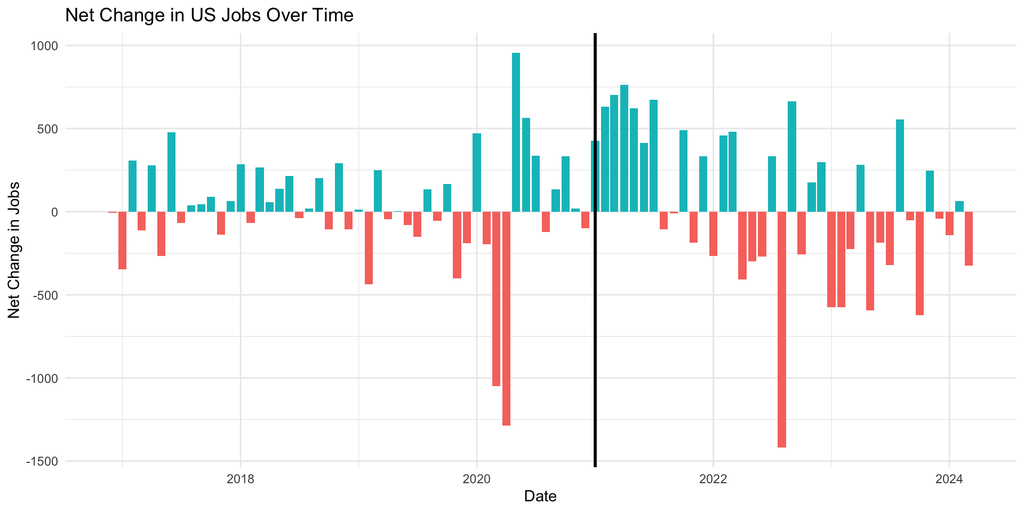

```r
# barplot
ggplot(jobs_data[-1,], aes(x = DATE, y = NetChange, fill = NetChange > 0)) +
  geom_bar(stat = "identity") +
  geom_vline(xintercept = as.Date("2021-01-01"), size =1) +
  labs(title = "Net Change in US Jobs Over Time",
       x = "Date",
       y = "Net Change in Jobs") +
  theme_minimal() +
  theme(legend.position = "none")
```

### Hot Dog Data (modified Yau’s original)

```r
hotdogs <- read_csv("https://raw.githubusercontent.com/lewv/sp25stats21/refs/heads/main/data/hotdogs.csv")
gt(hotdogs)
```

| Year | Winner | Dogs eaten | Country | New record |
| --- | --- | --- | --- | --- |
| 1980 | Paul Siederman & Joe Baldini | 9.10 | United States | 0 |
| 1981 | Thomas DeBerry | 11.00 | United States | 0 |
| 1982 | Steven Abrams | 11.00 | United States | 0 |
| 1983 | Luis Llamas | 19.50 | Mexico | 0 |
| 1984 | Birgit Felden | 9.50 | Germany | 0 |
| 1985 | Oscar Rodriguez | 11.75 | United States | 0 |
| 1986 | Mark Heller | 15.50 | United States | 0 |
| 1987 | Don Wolfman | 12.00 | United States | 0 |
| 1988 | Jay Green | 14.00 | United States | 0 |
| 1989 | Jay Green | 13.00 | United States | 0 |
| 1990 | Mike DeVito | 16.00 | United States | 0 |
| 1991 | Frank Dellarosa | 21.50 | United States | 1 |
| 1992 | Frank Dellarosa | 19.00 | United States | 0 |
| 1993 | Mike DeVito | 17.00 | United States | 0 |
| 1994 | Mike DeVito | 20.00 | United States | 0 |
| 1995 | Edward Krachie | 19.50 | United States | 0 |
| 1996 | Edward Krachie | 22.25 | United States | 1 |
| 1997 | Hirofumi Nakajima | 24.50 | Japan | 1 |
| 1998 | Hirofumi Nakajima | 19.00 | Japan | 0 |
| 1999 | Steve Keiner | 20.25 | United States | 0 |
| 2000 | Kazutoyo "The Rabbit" Arai | 25.13 | Japan | 1 |
| 2001 | Takeru Kobayashi | 50.00 | Japan | 1 |
| 2002 | Takeru Kobayashi | 50.50 | Japan | 1 |
| 2003 | Takeru Kobayashi | 44.50 | Japan | 0 |
| 2004 | Takeru Kobayashi | 53.50 | Japan | 1 |
| 2005 | Takeru Kobayashi | 49.00 | Japan | 0 |
| 2006 | Takeru "Tsunami" Kobayashi | 53.75 | Japan | 1 |
| 2007 | Joey Chestnut | 66.00 | United States | 1 |
| 2008 | Joey Chestnut | 59.00 | United States | 0 |
| 2009 | Joey Chestnut | 68.00 | United States | 1 |
| 2010 | Joey Chestnut | 54.00 | United States | 0 |
| 2011 | Joey Chestnut | 62.00 | United States | 0 |
| 2012 | Joey Chestnut | 68.00 | United States | 0 |
| 2013 | Joey Chestnut | 69.00 | United States | 1 |
| 2014 | Joey Chestnut | 61.00 | United States | 0 |
| 2015 | Matthew Stonie | 62.00 | United States | 0 |
| 2016 | Joey Chestnut | 70.00 | United States | 1 |
| 2017 | Joey Chestnut | 72.00 | United States | 1 |
| 2018 | Joey Chestnut | 74.00 | United States | 1 |
| 2019 | Joey Chestnut | 71.00 | United States | 0 |
| 2020 | Joey Chestnut | 75.00 | United States | 1 |
| 2021 | Joey Chestnut | 76.00 | United States | 1 |
| 2022 | Joey Chestnut | 63.00 | United States | 0 |
| 2023 | Joey Chestnut | 62.00 | United States | 0 |

### Histogram-like barplot

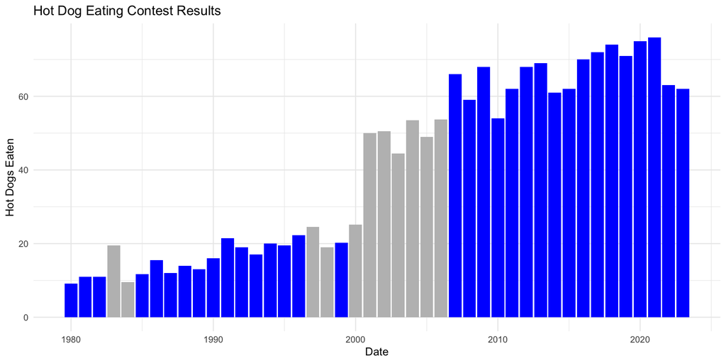

```r
# barplot
ggplot(hotdogs, aes(x = Year, y = `Dogs eaten`, fill = Country == "United States")) +
  geom_bar(stat = "identity") +
  scale_fill_manual(values = c("gray", "blue"), labels = c("Non-US", "US")) +
  labs(title = "Hot Dog Eating Contest Results",
       x = "Date",
       y = "Hot Dogs Eaten") +
  theme_minimal() +
  theme(legend.position = "none")
```

### Stacked barplot over time

Using a different dataset, this needs to be fixed a little bit, right now it is “wide format”

```r
adv_deg <- read_csv("https://raw.githubusercontent.com/lewv/sp25stats21/refs/heads/main/data/adv_deg.csv")
gt(adv_deg)
```

| YEAR | MS_PCT | Prof_PCT | PhD_PCT | MS | Prof | PhD |
| --- | --- | --- | --- | --- | --- | --- |
| 2015 | 8.7 | 1.6 | 1.7 | 18471 | 3365 | 3609 |
| 2016 | 9.3 | 1.5 | 1.8 | 19958 | 3178 | 3986 |
| 2017 | 9.5 | 1.5 | 1.9 | 20592 | 3172 | 4077 |
| 2018 | 9.6 | 1.4 | 2.0 | 21048 | 3172 | 4468 |
| 2019 | 10.0 | 1.4 | 2.0 | 22214 | 3136 | 4529 |
| 2020 | 10.5 | 1.5 | 2.1 | 23516 | 3362 | 4659 |
| 2021 | 10.7 | 1.5 | 2.1 | 24059 | 3443 | 4730 |
| 2022 | 10.6 | 1.5 | 2.1 | 23881 | 3444 | 4848 |

### Pivot to long (stacked data)

| YEAR | Degree | Pct |
| --- | --- | --- |
| 2015 | MS_PCT | 8.7 |
| 2015 | Prof_PCT | 1.6 |
| 2015 | PhD_PCT | 1.7 |
| 2016 | MS_PCT | 9.3 |
| 2016 | Prof_PCT | 1.5 |
| 2016 | PhD_PCT | 1.8 |
| 2017 | MS_PCT | 9.5 |
| 2017 | Prof_PCT | 1.5 |
| 2017 | PhD_PCT | 1.9 |
| 2018 | MS_PCT | 9.6 |
| 2018 | Prof_PCT | 1.4 |
| 2018 | PhD_PCT | 2.0 |
| 2019 | MS_PCT | 10.0 |
| 2019 | Prof_PCT | 1.4 |
| 2019 | PhD_PCT | 2.0 |
| 2020 | MS_PCT | 10.5 |
| 2020 | Prof_PCT | 1.5 |
| 2020 | PhD_PCT | 2.1 |
| 2021 | MS_PCT | 10.7 |
| 2021 | Prof_PCT | 1.5 |
| 2021 | PhD_PCT | 2.1 |
| 2022 | MS_PCT | 10.6 |
| 2022 | Prof_PCT | 1.5 |
| 2022 | PhD_PCT | 2.1 |

### Stacked Barplot

But a line plot may look better (probably a personal preference), should try to compare

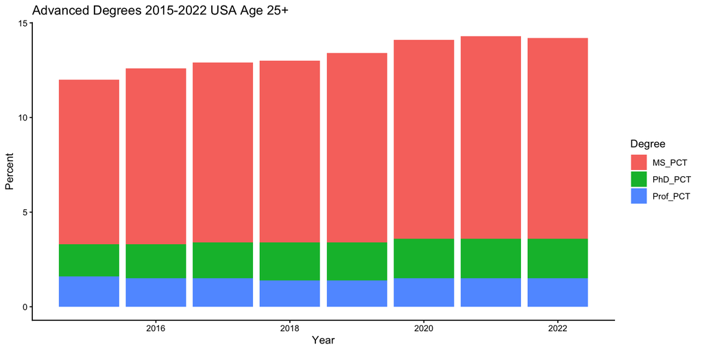

```r
# barplot
ggplot(degree_long, aes(x = YEAR, y = Pct, fill = Degree)) +
  geom_bar(stat = "identity") +
  labs(title = "Advanced Degrees 2015-2022 USA Age 25+",
       x = "Year",
       y = "Percent",
       fill = "Degree") +
  theme_classic()
```

### Point + Line plot

ggplot makes it easy because we only need to swap out the geoms_

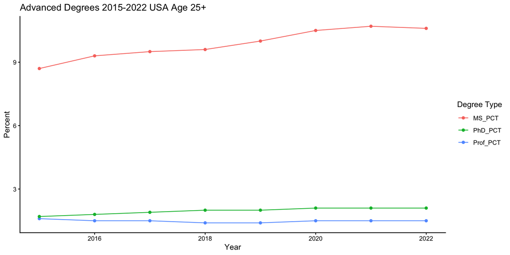

```r
ggplot(degree_long, aes(x = YEAR, y = Pct, color = Degree)) +
  geom_point() +
  geom_line() +
  labs(title = "Advanced Degrees 2015-2022 USA Age 25+",
       x = "Year",
       y = "Percent",
       color = "Degree Type") +
  theme_classic()
```

### Step plot

To demonstrate the discontinuous nature of price changes, a step plot might be useful

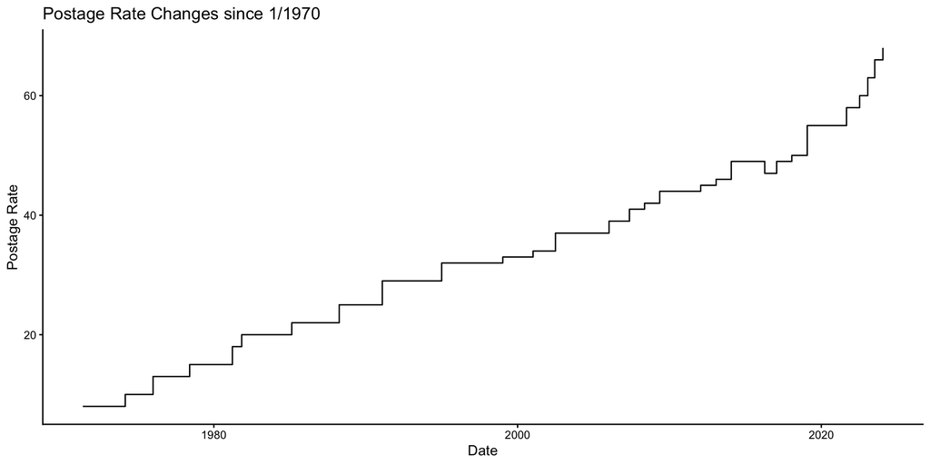

```r
postage <- read_csv("https://raw.githubusercontent.com/lewv/sp25stats21/refs/heads/main/data/postage.csv", col_types = cols(Date = col_date(format = "%B %d, %Y")))

postage <- postage %>% filter(Date > as.Date("1970-01-01"))

ggplot(postage, aes(x = Date, y = Cents)) +
  geom_step() +
  labs(title = "Postage Rate Changes since 1/1970",
       x = "Date",
       y = "Postage Rate") +
  theme_classic()
```

### Step plot + points

adding points to highlight the rapidity of price changes

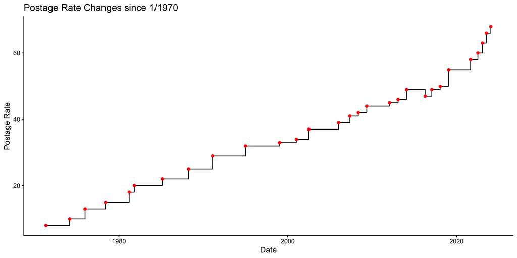

```r
ggplot(postage, aes(x = Date, y = Cents)) +
  geom_step() +
  geom_point(color = "red") +
  labs(title = "Postage Rate Changes since 1/1970",
       x = "Date",
       y = "Postage Rate") +
  theme_classic()
```

### Line plot

Just to compare

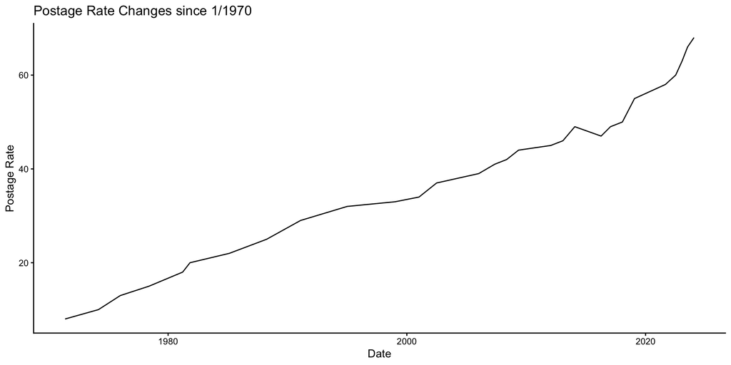

```r
ggplot(postage, aes(x = Date, y = Cents)) +
  geom_line() +
  labs(title = "Postage Rate Changes since 1/1970",
       x = "Date",
       y = "Postage Rate") +
  theme_classic()
```

### Smoothing

Sometimes, a line might be misleading. Jobs data is volatile and discontinuous

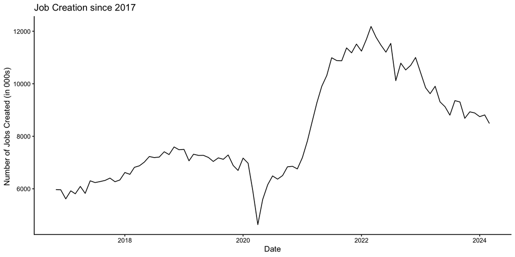

```r
ggplot(fredjobs, aes(x = DATE, y = JTSJOL)) +
  geom_line() +
  labs(
       title = "Job Creation since 2017",
       x = "Date",
       y = "Number of Jobs Created (in 000s) "
  ) +
  theme_classic()
```

### Smoothing

Default method is NULL so loess is used when there are less than 1000 observations. R tell us what it is using.

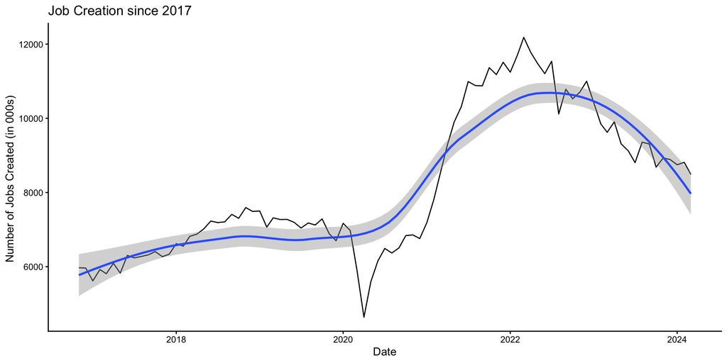

```r
ggplot(fredjobs, aes(x = DATE, y = JTSJOL)) +
  geom_line() +
  geom_smooth() +
  labs(
       title = "Job Creation since 2017",
       x = "Date",
       y = "Number of Jobs Created (in 000s) "
  ) +
  theme_classic()
```

### Smoothing - adjust span

span adjusts the faction of points used to fit each local regression, smaller values have more “wiggle”

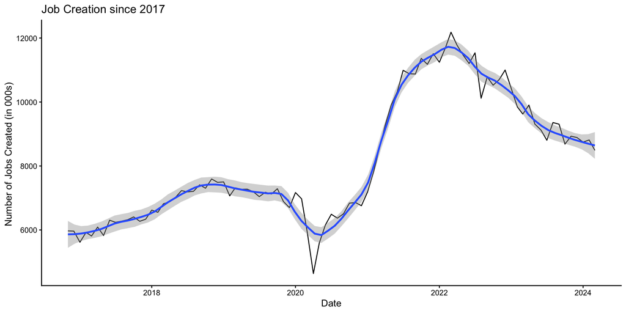

```r
ggplot(fredjobs, aes(x = DATE, y = JTSJOL)) +
  geom_line() +
  geom_smooth(span = 0.2) +
  labs(
       title = "Job Creation since 2017",
       x = "Date",
       y = "Number of Jobs Created (in 000s) "
  ) +
  theme_classic()
```

### Smoothing - adjust span

span adjusts the faction of points used to fit each local regression

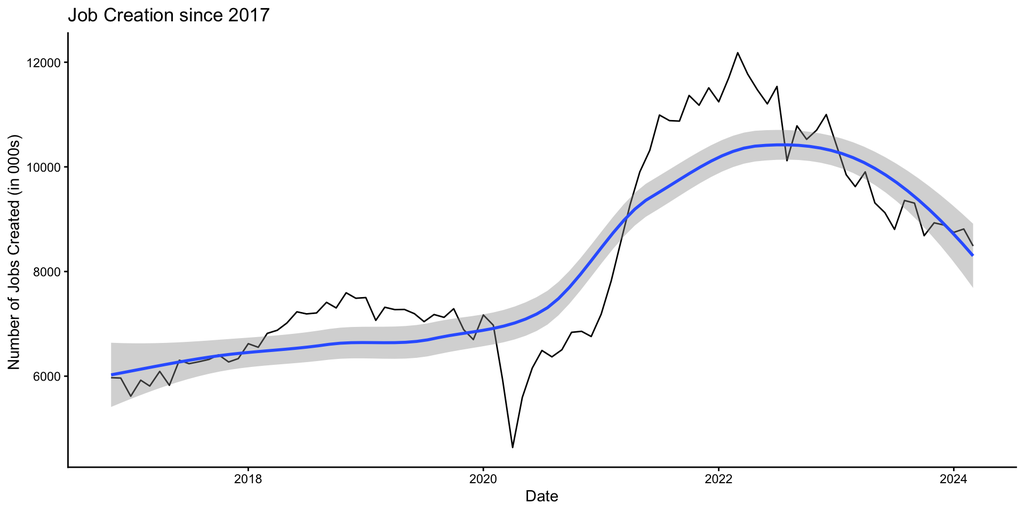

```r
ggplot(fredjobs, aes(x = DATE, y = JTSJOL)) +
  geom_line() +
  geom_smooth(span = 0.8) +
  labs(
       title = "Job Creation since 2017",
       x = "Date",
       y = "Number of Jobs Created (in 000s) "
  ) +
  theme_classic()
```

### Smoothing (lm)

A straight line doesn’t really work, too heavy-handed in its “smoothing”

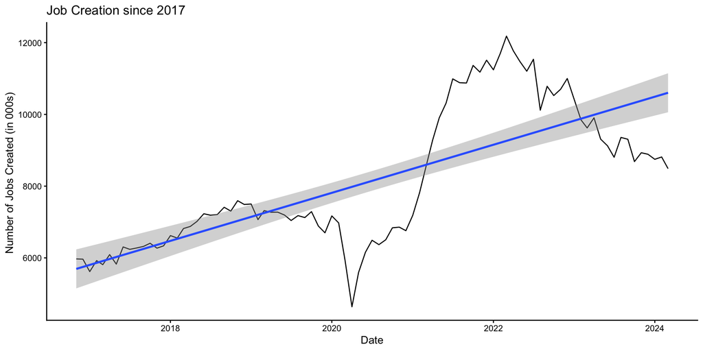

```r
ggplot(fredjobs, aes(x = DATE, y = JTSJOL)) +
  geom_line() +
  geom_smooth(method = "lm") +
  labs(
       title = "Job Creation since 2017",
       x = "Date",
       y = "Number of Jobs Created (in 000s) "
  ) +
  theme_classic()
```

### Smoothing other methods

You can add “knots” to capture the variation you seek.

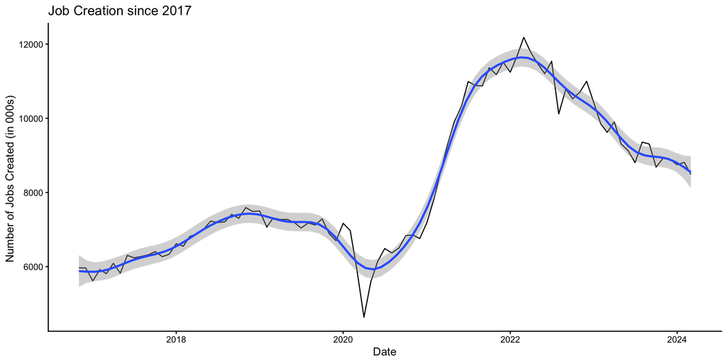

```r
ggplot(fredjobs, aes(x = DATE, y = JTSJOL)) +
  geom_line() +
  geom_smooth(method = "gam", formula = y ~ s(x, k = 20)) +
  labs(
       title = "Job Creation since 2017",
       x = "Date",
       y = "Number of Jobs Created (in 000s) "
  ) +
  theme_classic()
```